# Análisis desempleo recién graduados ingeniería en sistemas UNAH

Jonathan Melgar

18/5/2020

## Introducción

En este análisis se estudiará las causas de desempleo en los recién graduados de ingeniería en sistemas mostrando el procedimiento de tratamiento de datos de la encuesta realizada a estudiantes recién graduados de de esta carrera especificamente de la UNAH para determinar qué aspectos se debe tomar en cuenta o fortalecer para mejorar la empleabilidad de los estudiantes por egresar segun los resultados obtenidos.

## Variables capturadas

```
## 'data.frame':    59 obs. of  6 variables:
##  $ eleccion_estudio    : chr  "Sí" "Sí" "Sí" "Sí" ...
##  $ excelencia_academica: chr  "No" "No" "No" "Sí" ...
##  $ promedio_graduacion : int  75 79 78 80 78 79 79 76 75 78 ...
##  $ clases_por_periodo  : int  4 4 4 4 4 4 4 4 4 4 ...
##  $ anio_graduacion     : int  2019 2019 2019 2019 2019 2018 2019 2020 2020 2020 ...
##  $ trabajo_actual      : chr  "Sí" "Sí" "No" "Sí" ...
```

Para este pequeño análisis se obtuvieron 59 observaciones y 6 columnas que fueron tomadas de la encuesta completa que cuenta con 59 observaciones y 51 columnas las cuales estan organizadas en las siguientes categorias:

1. Demográficas
2. Rendimiento universitario
3. Post-universidad
4. Hardskills
5. Softskills

Encuesta completa:

```
## 'data.frame':    59 obs. of  51 variables:
##  $ timestamp                    : chr  "2020/04/07 3:14:21 PM CDT" "2020/04/07 3:32:48 PM CDT" "2020/04/07 5:01:27 PM CDT" "2020/04/07 5:07:30 PM CDT" ...
##  $ genero                       : chr  "Hombre" "Hombre" "Hombre" "Hombre" ...
##  $ edad                         : int  26 26 26 27 33 26 26 24 26 25 ...
##  $ procedencia                  : chr  "Cerro de Hula" "La ceiba, atlantida " "Tegucigalpa " "Tegucigalpa" ...
##  $ eleccion_estudio             : chr  "Sí" "Sí" "Sí" "Sí" ...
##  $ carrera_simultanea           : chr  "No" "No" "No" "No" ...
##  $ cambio_carrera               : chr  "Sí" "No" "No" "Sí" ...
##  $ becado                       : chr  "No" "No" "No" "No" ...
##  $ excelencia_academica         : chr  "No" "No" "No" "Sí" ...
##  $ promedio_graduacion          : int  75 79 78 80 78 79 79 76 75 78 ...
##  $ trabajo_y_estudio            : chr  "Sí" "Sí" "No" "No" ...
##  $ clases_por_periodo           : int  4 4 4 4 4 4 4 4 4 4 ...
##  $ tiempo_graduacion            : int  8 6 7 7 10 5 5 6 8 5 ...
##  $ rendimiento_docente          : chr  "El 50% eran buenos dando la clase" "El 70% eran buenos dando la clase" "El 50% eran buenos dando la clase" "El 60% eran buenos dando la clase" ...
```

[output cut: 37 more lines]

A continuación un pequeño resumen (Summary) de las 6 columnas o variables seleccionadas para este análisis:

```
##  eleccion_estudio   excelencia_academica promedio_graduacion clases_por_periodo
##  Length:59          Length:59            Min.   :  66.0      Min.   :3
##  Class :character   Class :character     1st Qu.:  76.5      1st Qu.:4
##  Mode  :character   Mode  :character     Median :  78.0      Median :4
##                                          Mean   : 111.1      Mean   :4
##                                          3rd Qu.:  80.0      3rd Qu.:4
##                                          Max.   :2019.0      Max.   :5
##
##  anio_graduacion trabajo_actual
##  Min.   :2016    Length:59
##  1st Qu.:2019    Class :character
##  Median :2019    Mode  :character
##  Mean   :2036
##  3rd Qu.:2020
##  Max.   :3000
##  NA's   :2
```

## Tratamiento de columnas

En el tratamiento de los datos lo mas común es que se realice la detección de valores nulos y transformaciones, de las 6 variables o columnas a analizar.

```
##  int [1:59] 75 79 78 80 78 79 79 76 75 78 ...
```

```
##  Factor w/ 17 levels "66","69","72",..: 5 9 8 10 8 9 9 6 5 8 ...
```

```
##  int [1:59] 4 4 4 4 4 4 4 4 4 4 ...
```

```
##  Factor w/ 3 levels "3","4","5": 2 2 2 2 2 2 2 2 2 2 ...
```

```
##  [1] 2019 2019 2019 2019 2019 2018 2019 2020 2020 2020 2020 2020 2020 2020   NA
## [16] 2020 2019 2019 2019 2019 2019 2019 2019   NA 2019 2019 2018 2016 2017 2020
## [31] 2019 2020 2020 2020 2020 2020 2019 2019 2018 2020 2019 2019 2020 2020 2019
## [46] 2020 2019 2019 2017 2018 2017 2018 2020 2019 3000 2020 2019 2019 2019
```

```
##  Factor w/ 6 levels "2016","2017",..: 4 4 4 4 4 3 4 5 5 5 ...
```

#### Limpiando valores nulos

```
##  eleccion_estudio   excelencia_academica promedio_graduacion clases_por_periodo
##  Length:59          Length:59            78     :12          3: 8
##  Class :character   Class :character     79     :11          4:43
##  Mode  :character   Mode  :character     75     : 8          5: 8
##                                          80     : 5
##                                          77     : 4
##                                          81     : 4
##                                          (Other):15
##  anio_graduacion trabajo_actual
##  2016: 1         Length:59
##  2017: 3         Class :character
##  2018: 5         Mode  :character
##  2019:27
##  2020:20
##  3000: 1
##  NA's: 2
```

```
## [1] "eleccion_estudio"
## [1] "excelencia_academica"
## [1] "promedio_graduacion"
## [1] "clases_por_periodo"
## [1] "anio_graduacion"
## [1] "trabajo_actual"
```

```r
na.summay %>% arrange(-na.percentage) %>% filter(na.percentage > 0)
```

```
##       column.name na.percentage
## 1 anio_graduacion    0.03389831
```

```r
variables_estudio$anio_graduacion <- as.numeric(paste(variables_estudio$anio_graduacion))
x <- variables_estudio %>% filter(!is.na(anio_graduacion))
media <- median(x$anio_graduacion)
variables_estudio[is.na(variables_estudio$anio_graduacion),"anio_graduacion"] <- media
variables_estudio$anio_graduacion <- as.factor(variables_estudio$anio_graduacion)
```

## Análisis descriptivo

En esta sección se describirán mediante gráficos los datos recopilados de las diferentes variables su comportamiento y mencion de valores atípicos en caso de que los hayan, además de las transformaciones realizadas.

#### Clases por periodo

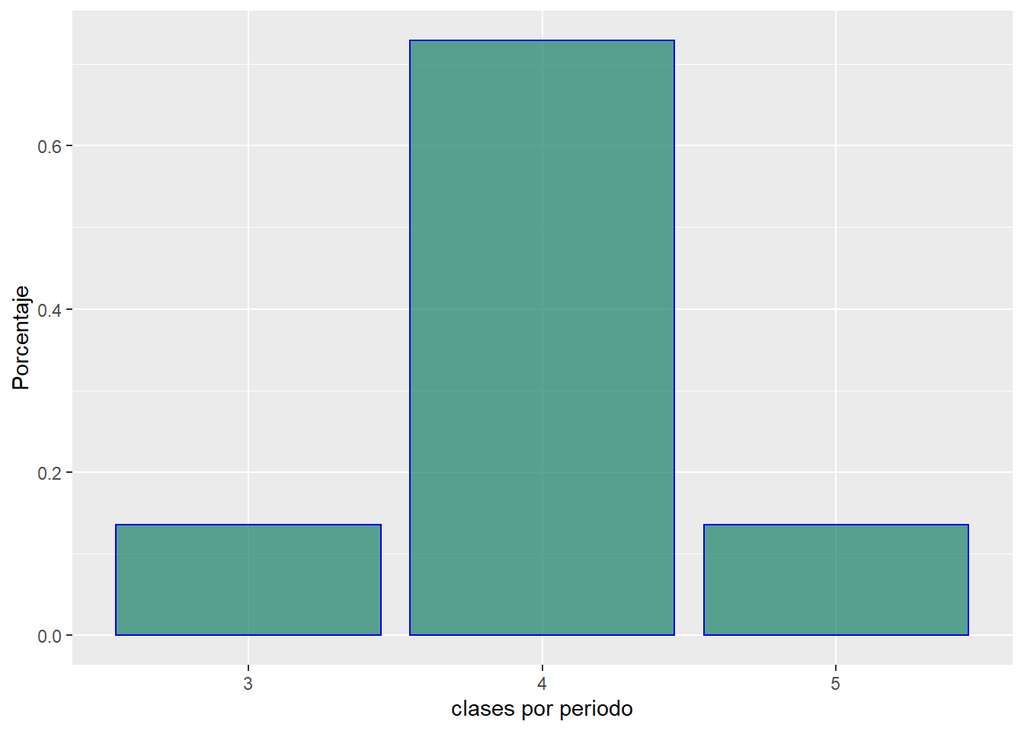

Estos valores podrían servir para medir de manera subjetiva el nivel de esfuerzo que tenían los encuestados en su etapa de estudiantes, por la condición de que algunas personas trabajan y estudian no son capaces de cursar el mismo número de clases que las que no cuentan con empleo y se dedican solo al estudio aún así el valor más común es 4 que se encuentra dentro del rango de lo sugerido por el plan de estudios.

#### Anio graduación

```
##    Min. 1st Qu.  Median    Mean 3rd Qu.    Max.
##    2016    2019    2019    2036    2020    3000
```

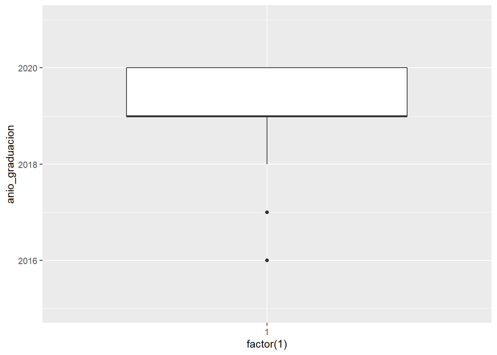

#### Promedio graduación

```
##    Min. 1st Qu.  Median    Mean 3rd Qu.    Max.
##   66.00   76.50   78.00   78.22   80.00   90.00
```

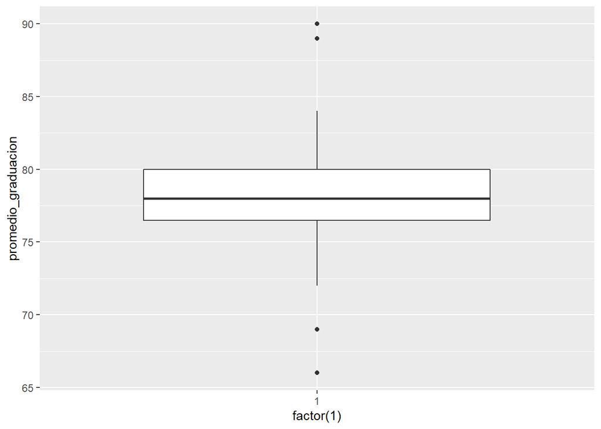

Un gráfico de caja que pareció la opción más viable para representar estos valores tan diversos, y es que encontramos valores bastante atípicos tanto por encima como debajo del rango intercuartílico. Más adelante en el análisis correlacional se estudiara si estos valores atípicos dependen de las clases que se llevaban por periodo.

#### Trabajo actual

```
##  [1] "Sí" "Sí" "No" "Sí" "No" "Sí" "Sí" "No" "No" "Sí" "Sí" "Sí" "No" "Sí" "Sí"
## [16] "Sí" "Sí" "Sí" "Sí" "Sí" "Sí" "Sí" "Sí" "Sí" "Sí" "Sí" "Sí" "Sí" "Sí" "Sí"
## [31] "Sí" "Sí" "Sí" "Sí" "Sí" "Sí" "Sí" "No" "Sí" "Sí" "Sí" "No" "Sí" "Sí" "Sí"
## [46] "No" "Sí" "No" "Sí" "Sí" "Sí" "Sí" "Sí" "Sí" "Sí" "No" "Sí" "Sí" "Sí"
```

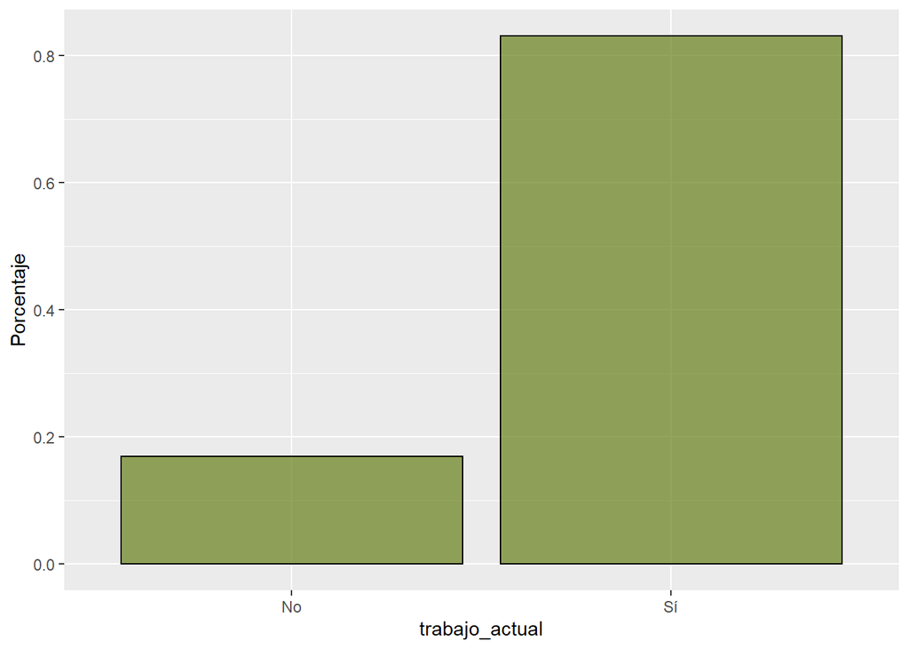

El porcentaje de empleabilidad en los estudiantes recién graduados de ingeniería en sistemas como se observa en la figura anterior es de más del 80% con menos del 20% desempleado a la actualidad.

## Rendimiento Universitario

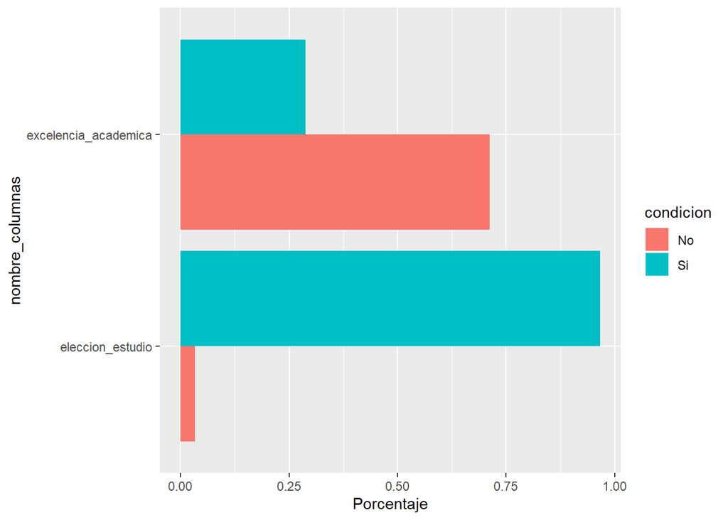

Los encuestados respondieron a estas preguntas binarias ofreciendo resultados que más adelante cotejados con otras variables de interés, permitirán hacer un análisis más complejo sobre aspectos que podrían repercutir en el estado laboral de los mismos.

Sin embargo, de manera general obtenemos que quienes no obtuvieron calificaciones que los posicionaran como estudiantes de excelencia académica doblan a los que sí lo consiguieron, también se observa que la mayor parte de los encuestados estudiaron la carrera de ingeniería en sistemas por elección propia.

## Correlaciones

Un estudio correlacional determina si dos variables están correlacionadas o no. Esto significa analizar si un aumento o disminución en una variable coincide con un aumento o disminución en la otra variable.

#### Correlación de variables categoricas

```r
prop.table(table(survey$eleccion_estudio,survey$excelencia_academica),1)
```

```
##
##             No        Sí
##   No 0.5000000 0.5000000
##   Sí 0.7192982 0.2807018
```

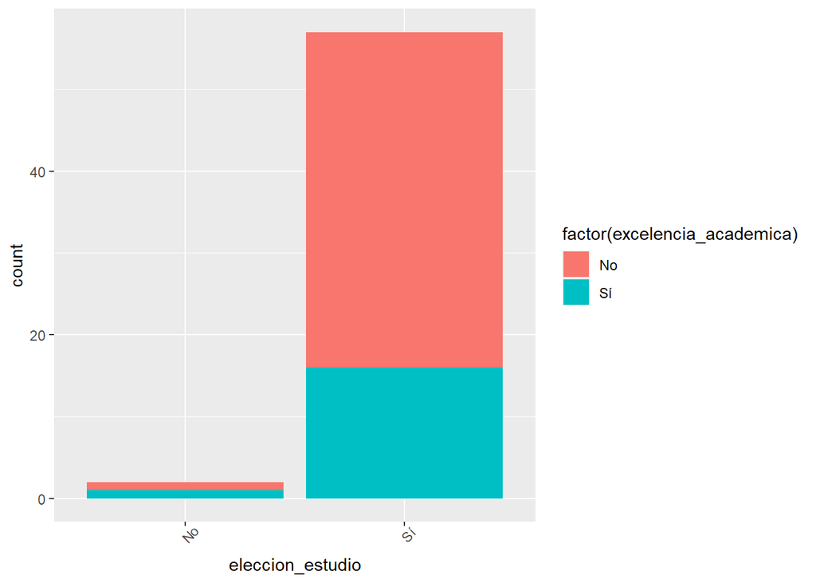

```r
ggplot(survey) +
  aes(x = eleccion_estudio, fill = factor(excelencia_academica)) +
  geom_bar(position = "stack") +
  theme(axis.text.x = element_text(angle = 45))
```

```r
chisq.test(table(survey$eleccion_estudio,survey$excelencia_academica))
```

```
##
##  Pearson's Chi-squared test with Yates' continuity correction
##
## data:  table(survey$eleccion_estudio, survey$excelencia_academica)
## X-squared = 1.2019e-31, df = 1, p-value = 1
```

#### Correlación de variables numerica/categorica

La correlación que se tratará en esta seccion es entre la variable promedio_graduacion y trabajo_actual.

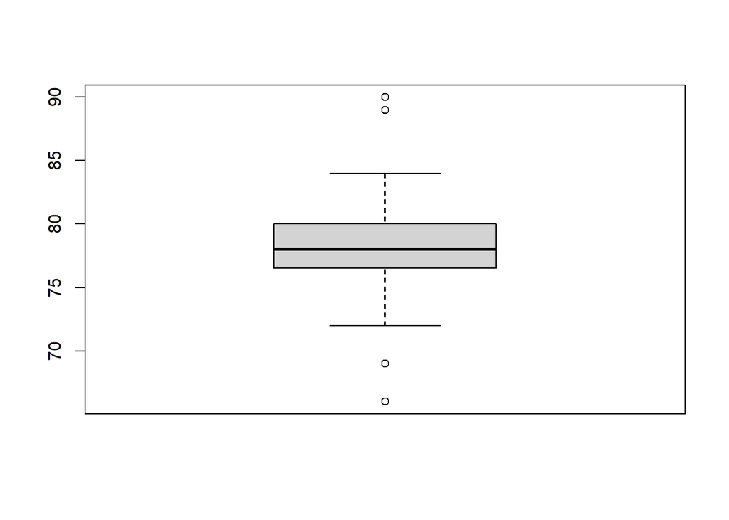

```
##
##  Shapiro-Wilk normality test
##
## data:  survey$promedio_graduacion
## W = 0.91713, p-value = 0.0006588
```

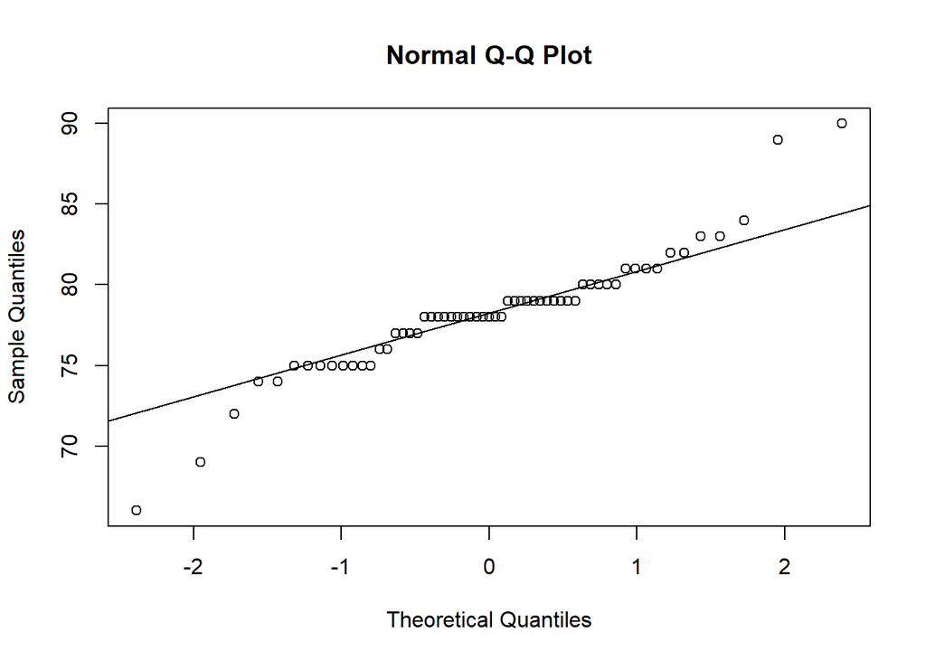

```
##  num [1:59] 75 79 78 80 78 79 79 76 75 78 ...
```

```
##
##  Shapiro-Wilk normality test
##
## data:  survey$promedio_graduacion
## W = 0.96257, p-value = 0.06677
```

##### Conclusión

Como se observa el valor de p-value es mayor a 0.05 por lo cual no podemos rechazar la hipotesis nula y la variable es normal.

Se procede a crear dos grupos uno para los egresados que si tienen empleo y otro para los que no tienen empleo.

```r
Si_trabaja <- survey %>% filter(trabajo_actual == "Sí") %>% select(promedio_graduacion)
no_trabaja <- survey %>% filter(trabajo_actual == "No") %>% select(promedio_graduacion)
```

#### Análisis para el grupo que si tiene empleo:

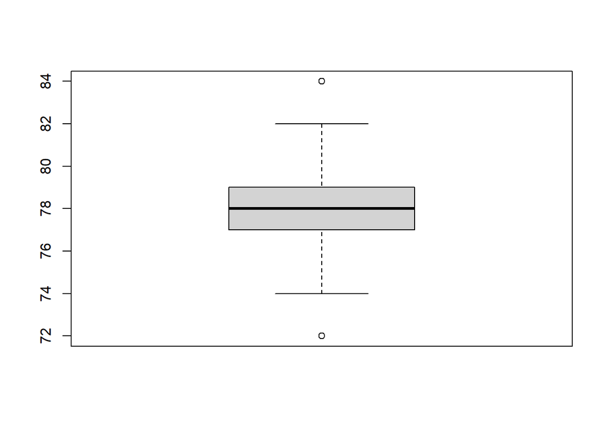

```r
boxplot(Si_trabaja$promedio_graduacion)
```

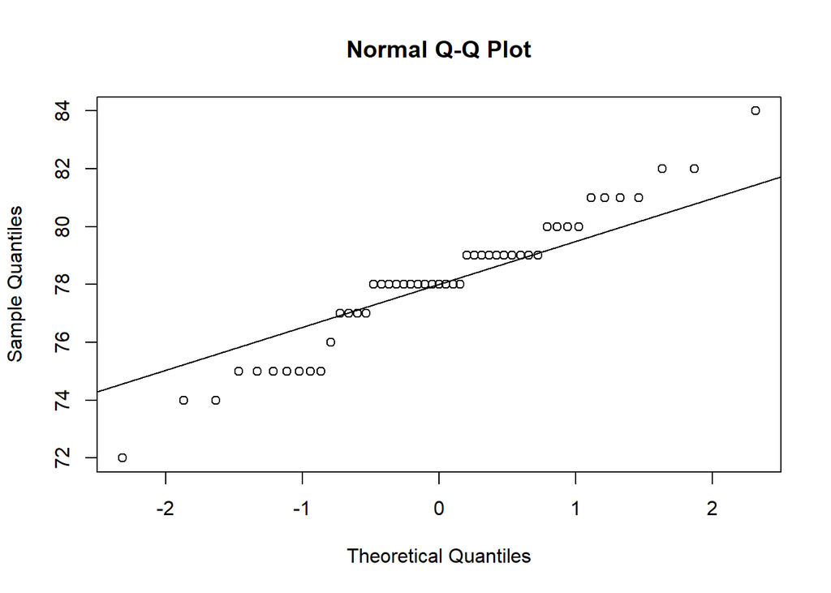

```r
qqnorm(Si_trabaja$promedio_graduacion)
qqline(Si_trabaja$promedio_graduacion)
```

```r
shapiro.test(Si_trabaja$promedio_graduacion)
```

```
##
##  Shapiro-Wilk normality test
##
## data:  Si_trabaja$promedio_graduacion
## W = 0.96224, p-value = 0.1172
```

##### Conclusión

El resultado de p-value es 0.1172 que es mayor a 0.05 por lo tanto no se puede rechazar la hipotesis nula y los datos son normales.

#### Análisis para el grupo que no tiene empleo:

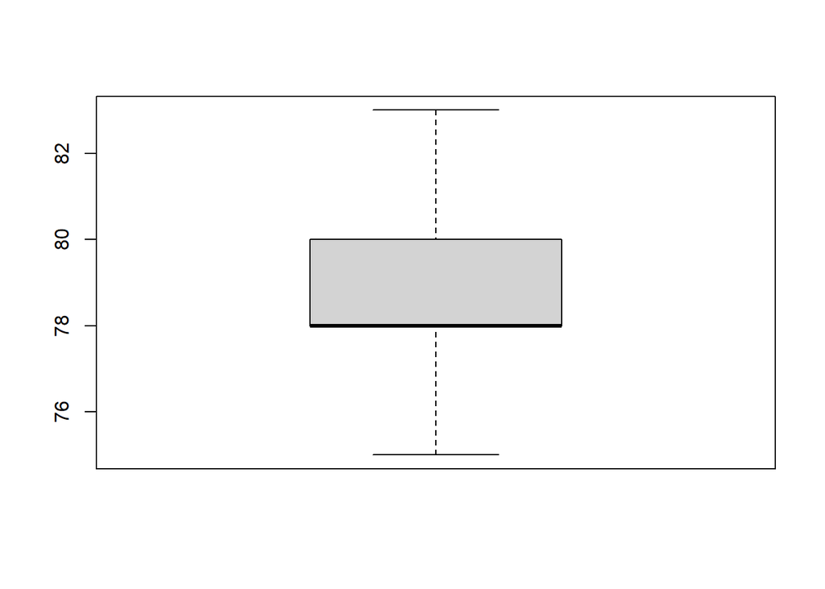

```r
boxplot(no_trabaja$promedio_graduacion)
```

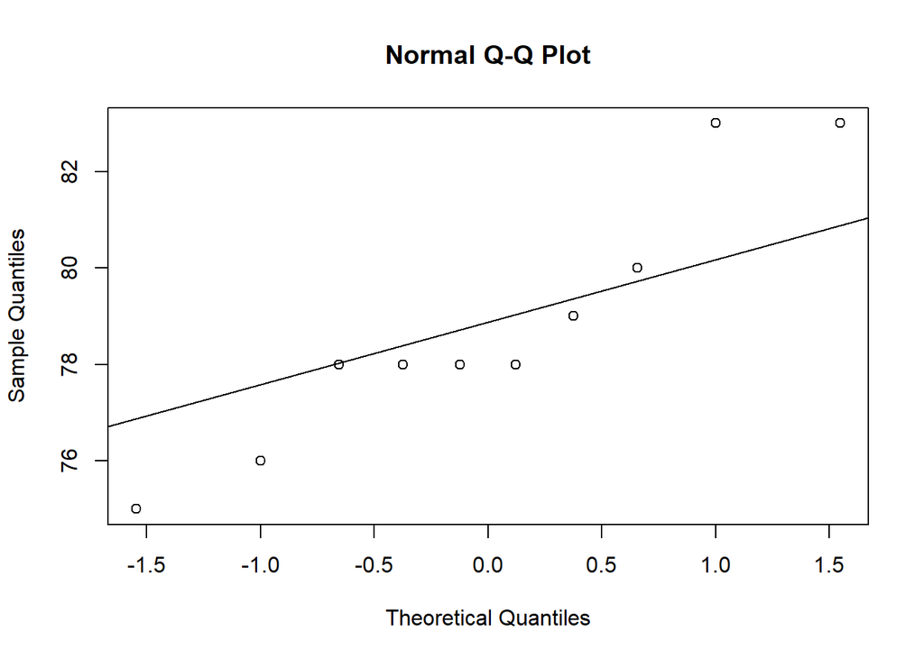

```r
qqnorm(no_trabaja$promedio_graduacion)
qqline(no_trabaja$promedio_graduacion)
```

```r
shapiro.test(no_trabaja$promedio_graduacion)
```

```
##
##  Shapiro-Wilk normality test
##
## data:  no_trabaja$promedio_graduacion
## W = 0.89956, p-value = 0.2167
```

##### Conclusión

El resultado de p-value es 0.2167 que es mayor a 0.05 por lo tanto no se puede rechazar la hipotesis nula y los datos son normales.

#### Prueba de homocedasticidad

```r
var.test(no_trabaja$promedio_graduacion,Si_trabaja$promedio_graduacion)
```

```
##
##  F test to compare two variances
##
## data:  no_trabaja$promedio_graduacion and Si_trabaja$promedio_graduacion
## F = 1.2221, num df = 9, denom df = 48, p-value = 0.6082
## alternative hypothesis: true ratio of variances is not equal to 1
## 95 percent confidence interval:
##  0.5108144 4.2500785
## sample estimates:
## ratio of variances
##           1.222148
```

#### Interpretación:

Con un p-value = 0.6082, mayor de 0.05, no podemos rechazar la hipótesis nula. Por lo tanto suponemos homogeneidad de varianzas.

```r
t.test( no_trabaja$promedio_graduacion,Si_trabaja$promedio_graduacion,
        alternative = "two.sided",
        paired = FALSE,
        var.equal = TRUE )
```

```
##
##  Two Sample t-test
##
## data:  no_trabaja$promedio_graduacion and Si_trabaja$promedio_graduacion
## t = 0.88428, df = 57, p-value = 0.3803
## alternative hypothesis: true difference in means is not equal to 0
## 95 percent confidence interval:
##  -0.9341874  2.4117385
## sample estimates:
## mean of x mean of y
##  78.80000  78.06122
```

#### Interpretación:

Con un p-value = 0.3803, mayor de 0.05, no podemos rechazar la hipótesis nula. Por lo tanto suponemos que las medias de los grupos son iguales.

#### Correlación de variables numéricas

```
## 'data.frame':    59 obs. of  2 variables:
##  $ clases_por_periodo : num  4 4 4 4 4 4 4 4 4 4 ...
##  $ promedio_graduacion: num  75 79 78 80 78 79 79 76 75 78 ...
```

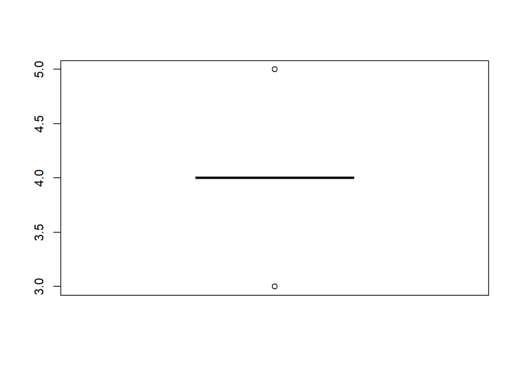

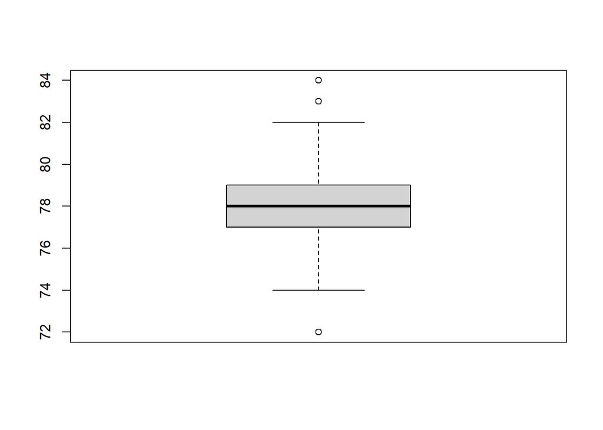

```
##                     clases_por_periodo promedio_graduacion
## clases_por_periodo              1.0000              0.1366
## promedio_graduacion             0.1366              1.0000
```

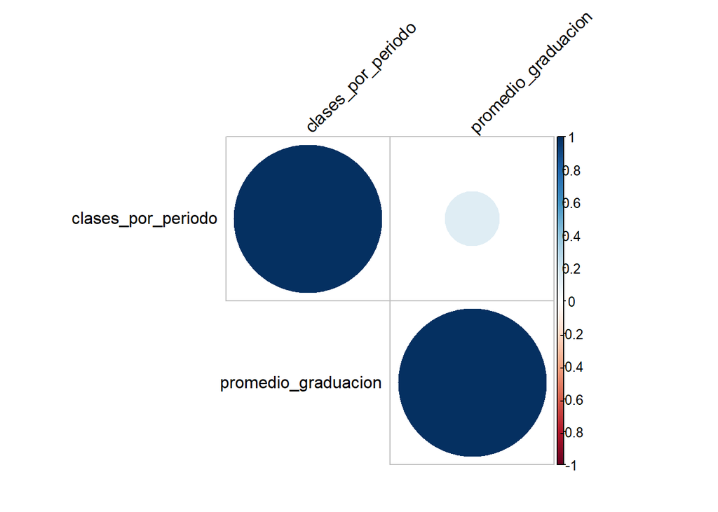

Sorprende ver el poco impacto que tienen las clases que llevaba por periodo un estudiante en su promedio de graduacion a penas del 13%.

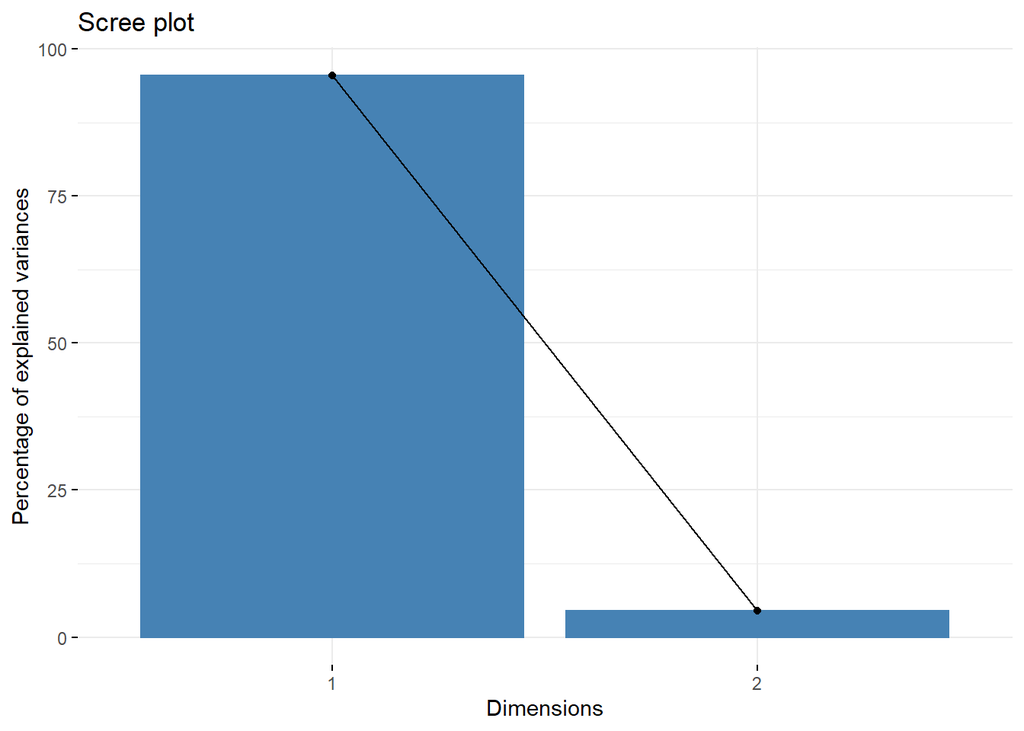

```r
res <- prcomp(numeric_corr2,scale=F)
fviz_eig(res)
```

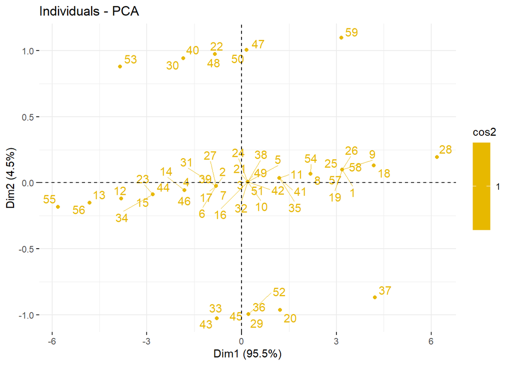

```r
fviz_pca_ind(res,
             col.ind = "cos2", # Color by the quality of representation
             gradient.cols = c("#00AFBB", "#E7B800", "#FC4E07"),
             repel = TRUE     # Avoid text overlapping
)
```

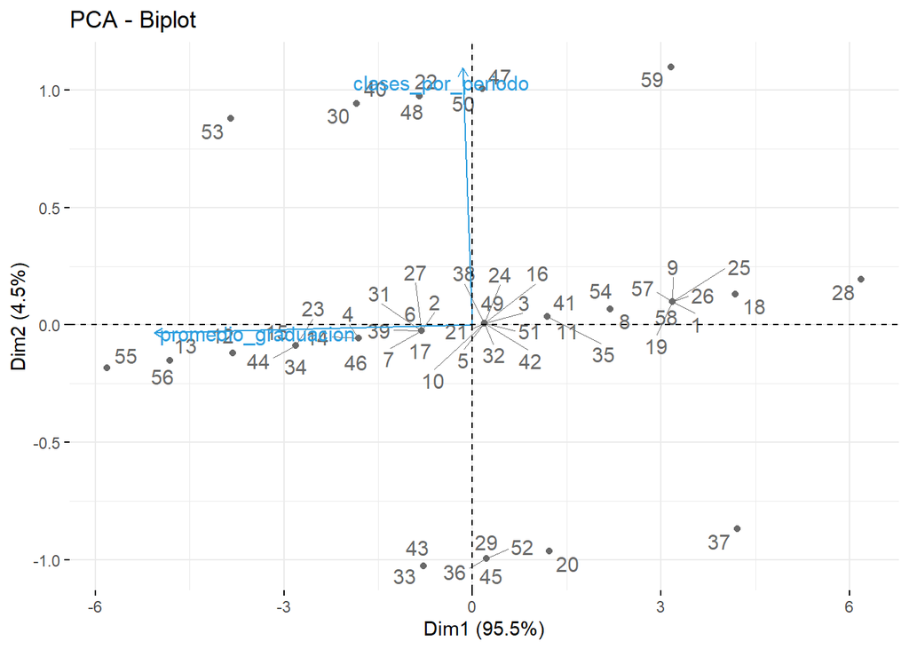

```r
fviz_pca_biplot(res, repel = TRUE,
                col.var = "#2E9FDF", # Variables color
                col.ind = "#696969"  # Individuals color
)
```

## Análisis explicativo

En nuestro caso de estudio la variable de respuesta y variable dependiente será la empleabilidad de los graduados de ingeniería en sistemas, dicha variable está definida en nuestra encuesta por la siguiente pregunta: ¿Actualmente tienes trabajo? En el siguiente bloque de codigo se realiza una regesión a nuestra variable dependiente junto a un conjunto de variables independientes analizando el impacto de estas en la variable de dolor.

```r
survey$tiene.empleo <- "0"
survey[survey$trabajo_actual == "No", "tiene.empleo"] <- "1"


 prop.table(table(survey$tiene.empleo))
```

```
##
##         0         1
## 0.8305085 0.1694915
```

```r
 vindependientes <- c(
    "genero",
    "edad",
    "nivel_ingles",
    "nivel_servidores",
    "nivel_programacion",
    "actividades_extracurriculares",
    "tiene.empleo"
  )

 datos_new <- survey[,names(survey) %in% vindependientes]

  datos_new$tiene.empleo <- as.factor(datos_new$tiene.empleo)

  modelo <- glm(tiene.empleo ~ .,  data= datos_new, family="binomial")

  centinela <- varImp(modelo)
  centinela$col <- row.names(centinela)
  centinela <- centinela %>% arrange(-Overall)
  centinela
```

```
##     Overall                             col
## 1 1.8034952                nivel_servidores
## 2 1.6496629                            edad
## 3 1.5789841              nivel_programacion
## 4 1.1251220 actividades_extracurricularesSí
## 5 0.7583042                     generoMujer
## 6 0.3686490                    nivel_ingles
```

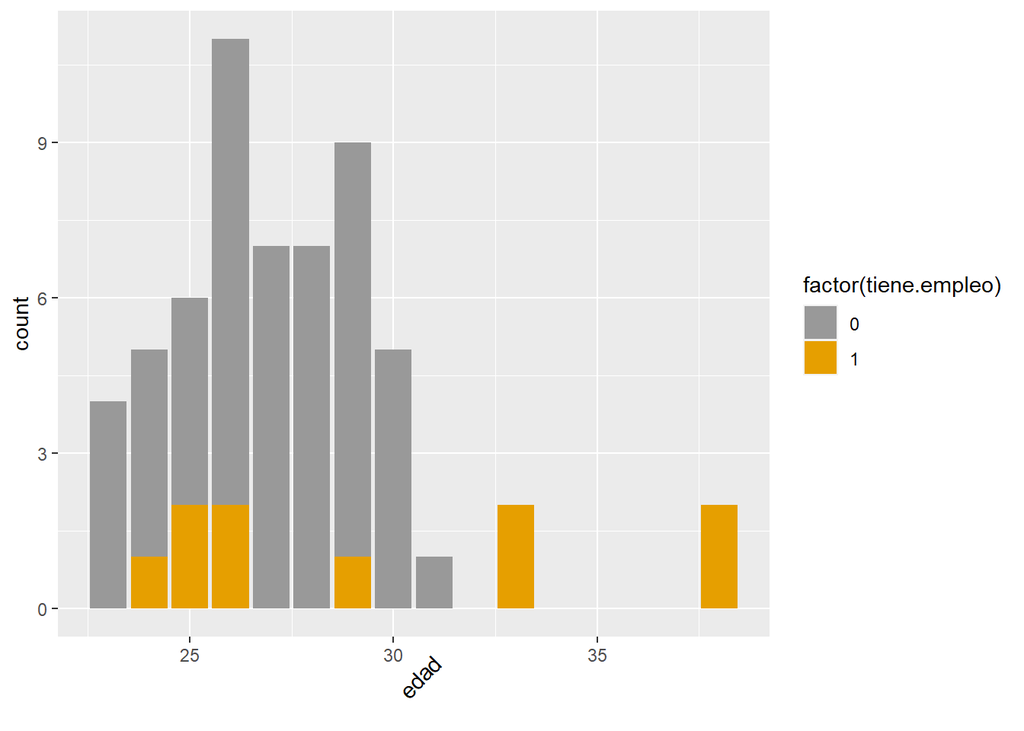

```r
  ggplot(datos_new) +
    aes(x=edad, fill=factor(tiene.empleo))+
    geom_bar(position = "stack")+
    theme(axis.title.x = element_text(angle = 45))+
    scale_fill_manual(values = c("#999999","#E69F00"))
```

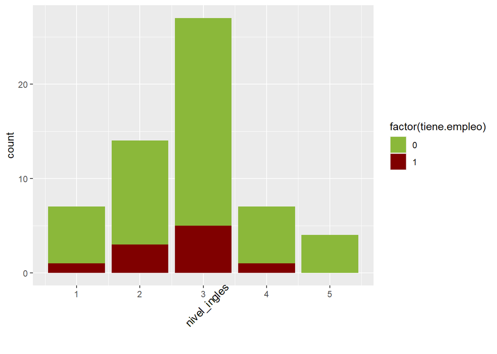

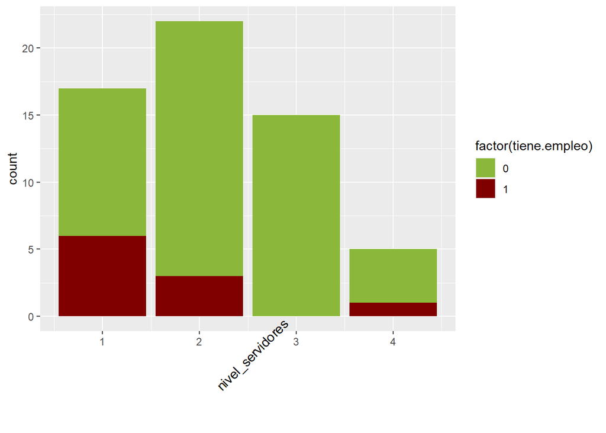

De los datos anteriores se puede concluir que los retos que un recien graduado se enfrenta van relacionados a la experiencia, y el nivel de conocimiento en areas sensibles como el ingles por ejemplo que las personas que estaban en un nivel avanzado contaban con 0% porciento de desempleo.

## Solución técnologica.

#### Comunicación

Nuestra solución tecnológica hace uso de la plataforma de AWS. Consiste en 3 partes de comunicación esencial para su efectiva funcionalidad. Primero tenemos la conexión Seguro social y UNAH que es donde vamos a compilar información importante del estudiante, seguido de Hadoop donde toda la información que obtengamos del seguro social y de la unah será manipulada en esta parte de la solución tecnológica. Y tenemos el portal del estudiante donde este estará almacenado en un EC2 en aws y se usará elastic beanstalk para desarrollar esta parte de la infraestructura. En el portal es donde el estudiante estará proporcionando su CV para poder ser analizado en hadoop con la información de la UNAH y del seguro social. Una vez analizada la información todo será regresado al portal del estudiante en el cual estará el estado de empleabilidad para que el lo vea o si se decide sera solo de acceso administrativo.

#### Seguro Social - UNAH

[figure not shown]

Seguro Social- UNAH.

[figure not shown]

Image

##### Portal web - AWS Elastic beanstalk

[figure not shown]

Image.

El portal web estará montando en los servidores de AWS y estaremos usando Elastic Beanstalk por razones de organización. Elastic Beanstalk es solo una integración con muchas otras tecnologías dentro de los servicios que ofrece AWS que en nuestro caso nos ayudará a mantener organizado nuestro trabajo y nos ahorra tiempo de configuración. Si bien es cierto, el portal sólo lo estarán viendo los estudiantes o los administradores de la carrera de ingeniería en sistemas, a nosotros los desarrolladores nos servirá para integrar toda la información que viene de hadoop y que va para hadoop.

#### Hadoop - AWS Glue

[figure not shown]

Image.

Una vez consumidas las APIs del Seguro Social y de la UNAH esta información se estar guardando en una base de datos relacional. Donde se estará utilizando AWS Glue como herramienta de Extracción, carga y transformación. Antes de enviar la información a Hadoop primero preparamos los datos y despues enviemos a Hadoop. Hadoop es un set de tecnologías para aplicaciones en forma de cluster que mayormente se utilizan para el trabajo de datos masivos. En nuestro caso estamos interesado en la interacción que tiene con computación distribuida y las capabilidades de la herramienta madura como Mahout para el desarrollo de algoritmos de aprendizaje automático. Una vez nuestra información se encuentre de forma ordenada en AWS glue, está pasara a Hadoop donde sera utlizara para entrenar y posteriormente se utilizará para decidir el nivel de empleabilidad de los CVs de diferentes alumnos de la carrera de ingeniería en sistema de la UNAH.

#### Presupuesto

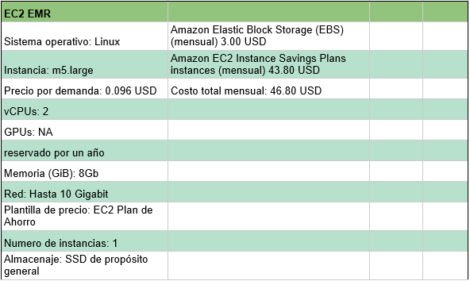

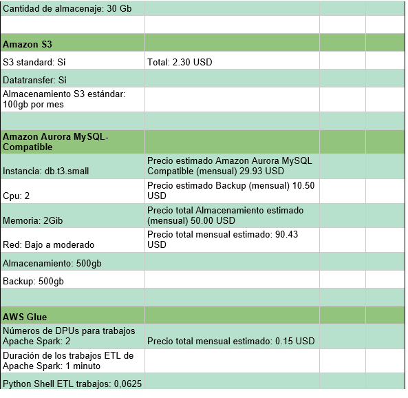

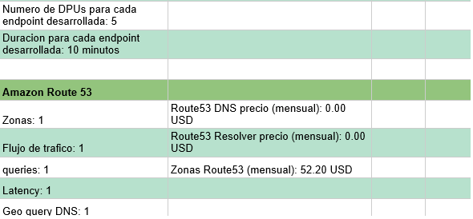

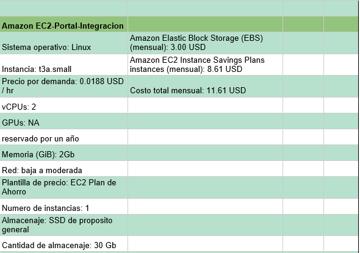

[figure not shown]

En total serian 2375 dolares americanos por año. Estamos confiados en que solo es un estimado ya que la calculadora de AWS no nos dejaba poner valores mínimos de cierto tiempo, tuvimos que elegir los datos que ellos pensaban deseables. Los primeros dos años serán los menos costosos ya que solo se están recopilando información y solo se estará pagando el mínimo para el dominio del portal y almacenamiento. Después de compilar información y ver que se tiene suficiente información necesaria para empezar a entrenar el algoritmo, se empezaría a utilizar los servicios de Hadoop para entrenar el algoritmo. Confiamos en que no sería mucho el tiempo de entrenamiento y esperamos un uso mínimo del servidor de Hadoop al entrenar el algoritmo. Nuevamente se utilizará el servidor de Hadoop para determinar el nivel de empleabilidad de cada estudiante y este se hará en batch para cortar costos. Se habilitaran una cantidad de días al empezar la matrícula para que el estudiante envíe su CV a la plataforma.